# Article - Sentiment d’appartenance

## Q39B. Dites si vous êtes tout à fait d’accord, plutôt d’accord, plutôt pas d’accord ou pas du tout d’accord avec les propositions suivantes (participation identitaire et sentiment d’appartenance) : il faut faire oublier ses origines pour se faire accepter au Québec.

```r
Base_Trajipaq_Finale_Ok <-
  Base_Trajipaq_Finale_Ok %>%
  mutate(Q39B = case_when(
    Q39B == 1 ~ 4,
    Q39B == 2 ~ 3,
    Q39B == 3 ~ 2,
    Q39B == 4 ~ 1,
    Q39B == 98 ~ NA,
    Q39B == 99 ~ NA
  ))
```

```r
freq(Base_Trajipaq_Finale_Ok$Q39B)
```

```
## Frequencies
## Base_Trajipaq_Finale_Ok$Q39B
## Type: Numeric
##
##               Freq   % Valid   % Valid Cum.   % Total   % Total Cum.
## ----------- ------ --------- -------------- --------- --------------
##           1    671     44.70          44.70     42.93          42.93
##           2    390     25.98          70.69     24.95          67.88
##           3    298     19.85          90.54     19.07          86.95
##           4    142      9.46         100.00      9.09          96.03
##        <NA>     62                               3.97         100.00
##       Total   1563    100.00         100.00    100.00         100.00
```

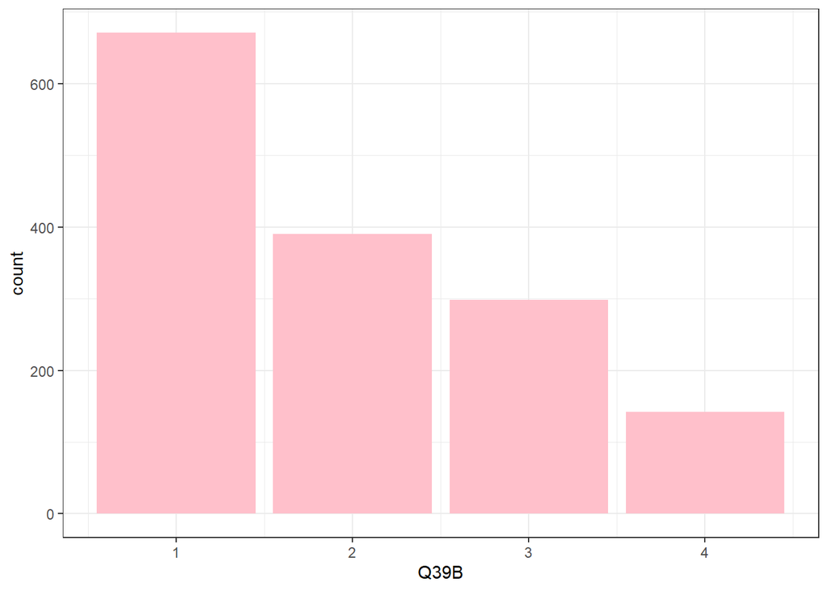

```r
ggplot(data = Base_Trajipaq_Finale_Ok, mapping = aes(x = Q39B)) +
  geom_bar(fill = "pink",
           na.rm = TRUE
           ) +
  theme_bw()
```

La distribution est asymétrique vers la droite. 67.88% des personnes interrogées ne sont pas du tout d’accord ou plutôt pas d’accord pour dire qu’il faut faire oublier ses origines pour se faire accepter au Québec.

## Q39C. Dites si vous êtes tout à fait d’accord, plutôt d’accord, plutôt pas d’accord ou pas du tout d’accord avec les propositions suivantes (participation identitaire et sentiment d’appartenance) : on me voit comme une Québécoise.

```r
Base_Trajipaq_Finale_Ok <-
  Base_Trajipaq_Finale_Ok %>%
  mutate(Q39C = case_when(
    Q39C == 1 ~ 4,
    Q39C == 2 ~ 3,
    Q39C == 3 ~ 2,
    Q39C == 4 ~ 1,
    Q39C == 98 ~ NA,
    Q39C == 99 ~ NA
  ))
```

```r
freq(Base_Trajipaq_Finale_Ok$Q39C)
```

```
## Frequencies
## Base_Trajipaq_Finale_Ok$Q39C
## Type: Numeric
##
##               Freq   % Valid   % Valid Cum.   % Total   % Total Cum.
## ----------- ------ --------- -------------- --------- --------------
##           1    442     29.97          29.97     28.28          28.28
##           2    341     23.12          53.08     21.82          50.10
##           3    259     17.56          70.64     16.57          66.67
##           4    433     29.36         100.00     27.70          94.37
##        <NA>     88                               5.63         100.00
##       Total   1563    100.00         100.00    100.00         100.00
```

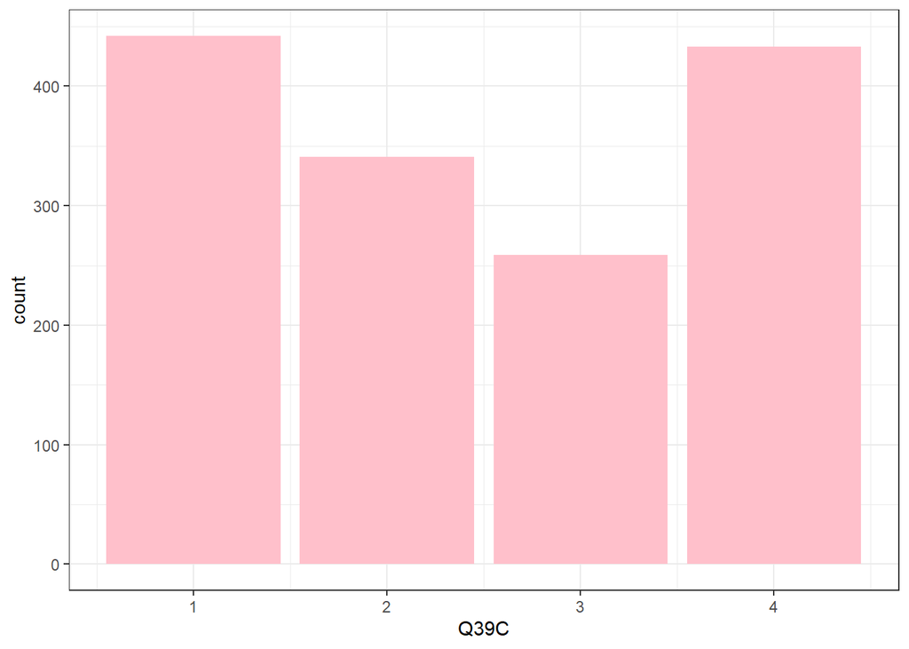

```r
ggplot(data = Base_Trajipaq_Finale_Ok, mapping = aes(x = Q39C)) +
  geom_bar(fill = "pink",
           na.rm = TRUE
           ) +
  theme_bw()
```

Les réponses modales sont “tout à fait d’accord” (29.36%) et “pas du tout d’accord” (29.97%).

## Q39D. Dites si vous êtes tout à fait d’accord, plutôt d’accord, plutôt pas d’accord ou pas du tout d’accord avec les propositions suivantes (participation identitaire et sentiment d’appartenance) : je me sens Québécois(e).

```r
Base_Trajipaq_Finale_Ok <-
  Base_Trajipaq_Finale_Ok %>%
  mutate(Q39D = case_when(
    Q39D == 1 ~ 4,
    Q39D == 2 ~ 3,
    Q39D == 3 ~ 2,
    Q39D == 4 ~ 1,
    Q39D == 98 ~ NA,
    Q39D == 99 ~ NA
  ))
```

```r
freq(Base_Trajipaq_Finale_Ok$Q39D)
```

```
## Frequencies
## Base_Trajipaq_Finale_Ok$Q39D
## Type: Numeric
##
##               Freq   % Valid   % Valid Cum.   % Total   % Total Cum.
## ----------- ------ --------- -------------- --------- --------------
##           1    259     17.27          17.27     16.57          16.57
##           2    292     19.47          36.73     18.68          35.25
##           3    406     27.07          63.80     25.98          61.23
##           4    543     36.20         100.00     34.74          95.97
##        <NA>     63                               4.03         100.00
##       Total   1563    100.00         100.00    100.00         100.00
```

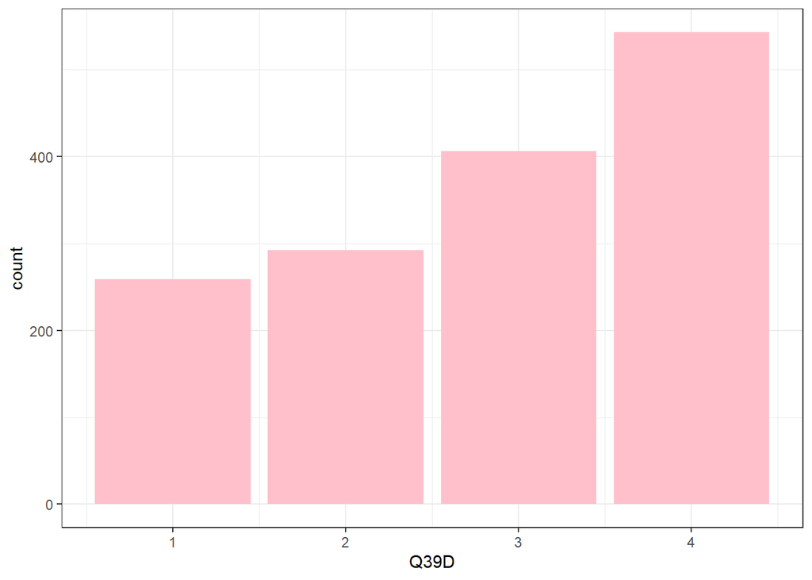

```r
ggplot(data = Base_Trajipaq_Finale_Ok, mapping = aes(x = Q39D)) +
  geom_bar(fill = "pink",
           na.rm = TRUE
           ) +
  theme_bw()
```

La distribution est asymétrique vers la gauche. 60.72% des personnes interrogées sont tout à fait d’accord ou plutôt d’accord pour dire qu’elles se sentent Québécois(e)s.

## Q39E. Dites si vous êtes tout à fait d’accord, plutôt d’accord, plutôt pas d’accord ou pas du tout d’accord avec les propositions suivantes (participation identitaire et sentiment d’appartenance) : je me sens Canadien(ne).

```r
Base_Trajipaq_Finale_Ok <-
  Base_Trajipaq_Finale_Ok %>%
  mutate(Q39E = case_when(
    Q39E == 1 ~ 4,
    Q39E == 2 ~ 3,
    Q39E == 3 ~ 2,
    Q39E == 4 ~ 1,
    Q39E == 98 ~ NA,
    Q39E == 99 ~ NA
  ))
```

```r
freq(Base_Trajipaq_Finale_Ok$Q39E)
```

```
## Frequencies
## Base_Trajipaq_Finale_Ok$Q39E
## Type: Numeric
##
##               Freq   % Valid   % Valid Cum.   % Total   % Total Cum.
## ----------- ------ --------- -------------- --------- --------------
##           1    100      6.57           6.57      6.40           6.40
##           2    171     11.24          17.82     10.94          17.34
##           3    550     36.16          53.98     35.19          52.53
##           4    700     46.02         100.00     44.79          97.31
##        <NA>     42                               2.69         100.00
##       Total   1563    100.00         100.00    100.00         100.00
```

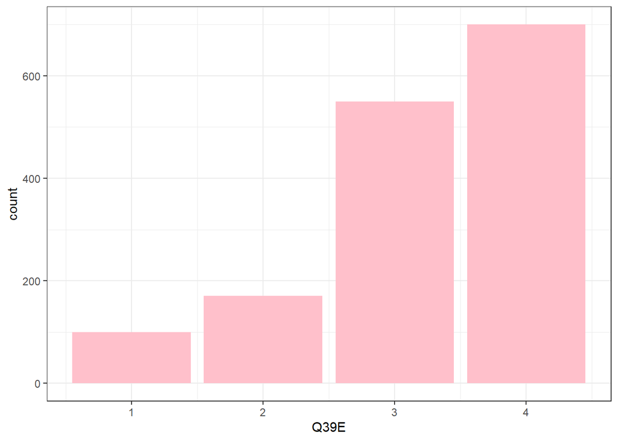

```r
ggplot(data = Base_Trajipaq_Finale_Ok, mapping = aes(x = Q39E)) +
  geom_bar(fill = "pink",
           na.rm = TRUE
           ) +
  theme_bw()
```

La distribution est asymétrique vers la gauche. 79.98% des personnes interrogées sont tout à fait d’accord ou plutôt d’accord pour dire qu’elles se sentent Canadien(ne).

## Q39F. Dites si vous êtes tout à fait d’accord, plutôt d’accord, plutôt pas d’accord ou pas du tout d’accord avec les propositions suivantes (participation identitaire et sentiment d’appartenance) : j’ai un sentiment d’appartenance à mon pays d’origine.

```r
Base_Trajipaq_Finale_Ok <-
  Base_Trajipaq_Finale_Ok %>%
  mutate(Q39F = case_when(
    Q39F == 1 ~ 4,
    Q39F == 2 ~ 3,
    Q39F == 3 ~ 2,
    Q39F == 4 ~ 1,
    Q39F == 98 ~ NA,
    Q39F == 99 ~ NA
  ))
```

```r
freq(Base_Trajipaq_Finale_Ok$Q39F)
```

```
## Frequencies
## Base_Trajipaq_Finale_Ok$Q39F
## Type: Numeric
##
##               Freq   % Valid   % Valid Cum.   % Total   % Total Cum.
## ----------- ------ --------- -------------- --------- --------------
##           1     82      5.44           5.44      5.25           5.25
##           2    198     13.14          18.58     12.67          17.91
##           3    550     36.50          55.08     35.19          53.10
##           4    677     44.92         100.00     43.31          96.42
##        <NA>     56                               3.58         100.00
##       Total   1563    100.00         100.00    100.00         100.00
```

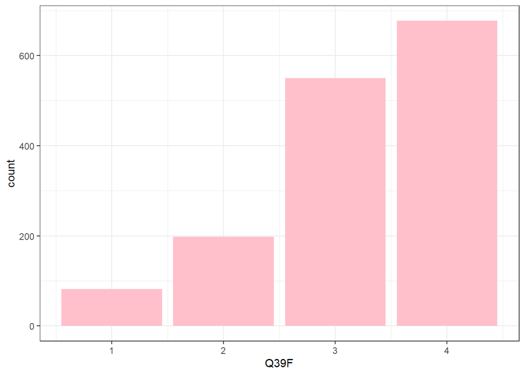

```r
ggplot(data = Base_Trajipaq_Finale_Ok, mapping = aes(x = Q39F)) +
  geom_bar(fill = "pink",
           na.rm = TRUE
           ) +
  theme_bw()
```

La distribution est asymétrique vers la gauche. 81.42% des personnes interrogées sont tout à fait d’accord ou plutôt d’accord pour dire qu’elles possèdent un sentiment d’appartenance envers leur pays d’origine.

## I1 : L’indice du sentiment d’appartenance au Québec

A la différence des variables précédentes, l’indice du sentiment d’appartenance est une variable numérique continue dont le niveau de mesure est ratio.

```r
v_I1 <- c("Q39A",
          "Q39B",
          "Q39C",
          "Q39D",
          "Q39E",
          "Q39F"
          )

Base_Trajipaq_Finale_Ok <-
  Base_Trajipaq_Finale_Ok %>%
  rowwise() %>%
  mutate(I1 = (sum(c_across(all_of(v_I1)), na.rm = TRUE) - length(v_I1)) / (3*length(v_I1))) %>%
  mutate(I1 = if (I1 < 0) NA_real_ else I1) %>%
  ungroup()
```

```r
descr(Base_Trajipaq_Finale_Ok$I1)
```

```
## Descriptive Statistics
## Base_Trajipaq_Finale_Ok$I1
## N: 1563
##
##                          I1
## ----------------- ---------
##              Mean      0.59
##           Std.Dev      0.21
##               Min      0.00
##                Q1      0.44
##            Median      0.61
##                Q3      0.72
##               Max      1.00
##               MAD      0.25
##               IQR      0.28
##                CV      0.35
##          Skewness     -0.30
##       SE.Skewness      0.06
##          Kurtosis     -0.41
##           N.Valid   1550.00
##         Pct.Valid     99.17
```

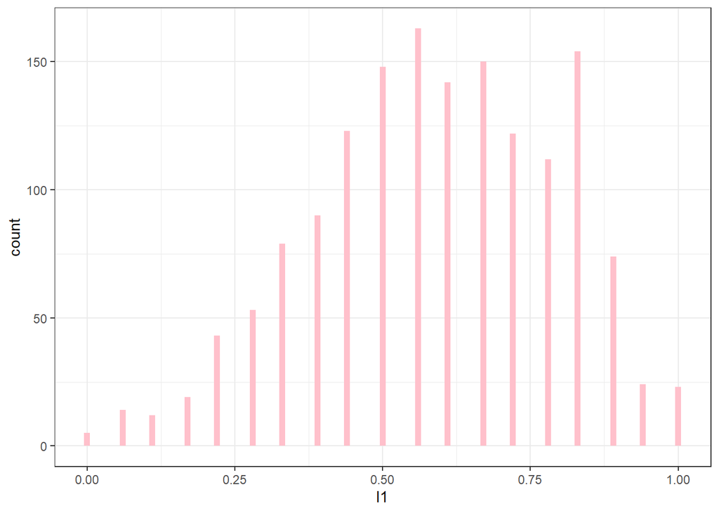

```r
ggplot(data = Base_Trajipaq_Finale_Ok, mapping = aes(x = I1)) +
  geom_histogram(na.rm = TRUE, fill = "pink", binwidth = 0.01) +
  theme_bw()
```

La distribution est asymétrique vers la gauche. L’indice moyen du sentiment d’appartenance au Québec est 0.59.

# Présentation de la variable dépendante

## Q40A. Au cours des 12 mois (avant la crise de la COVID-19), pensez-vous avoir subi des traitements inégalitaires ou des discriminations ? Un traitement inégalitaire ou une discrimination se repère si « vous avez été moins bien traité que les autres, sans raison valable » : dans l’emploi ?

```r
Base_Trajipaq_Finale_Ok <-
  Base_Trajipaq_Finale_Ok %>%
  mutate(Q40A = case_when(
    Q40A == 1 ~ 3,
    Q40A == 2 ~ 2,
    Q40A == 3 ~ 1,
    Q40A == 96 ~ NA,
    Q40A == 98 ~ NA,
    Q40A == 99 ~ NA
  ))
```

```r
freq(Base_Trajipaq_Finale_Ok$Q40A)
```

```
## Frequencies
## Base_Trajipaq_Finale_Ok$Q40A
## Type: Numeric
##
##               Freq   % Valid   % Valid Cum.   % Total   % Total Cum.
## ----------- ------ --------- -------------- --------- --------------
##           1    926     65.44          65.44     59.25          59.25
##           2    383     27.07          92.51     24.50          83.75
##           3    106      7.49         100.00      6.78          90.53
##        <NA>    148                               9.47         100.00
##       Total   1563    100.00         100.00    100.00         100.00
```

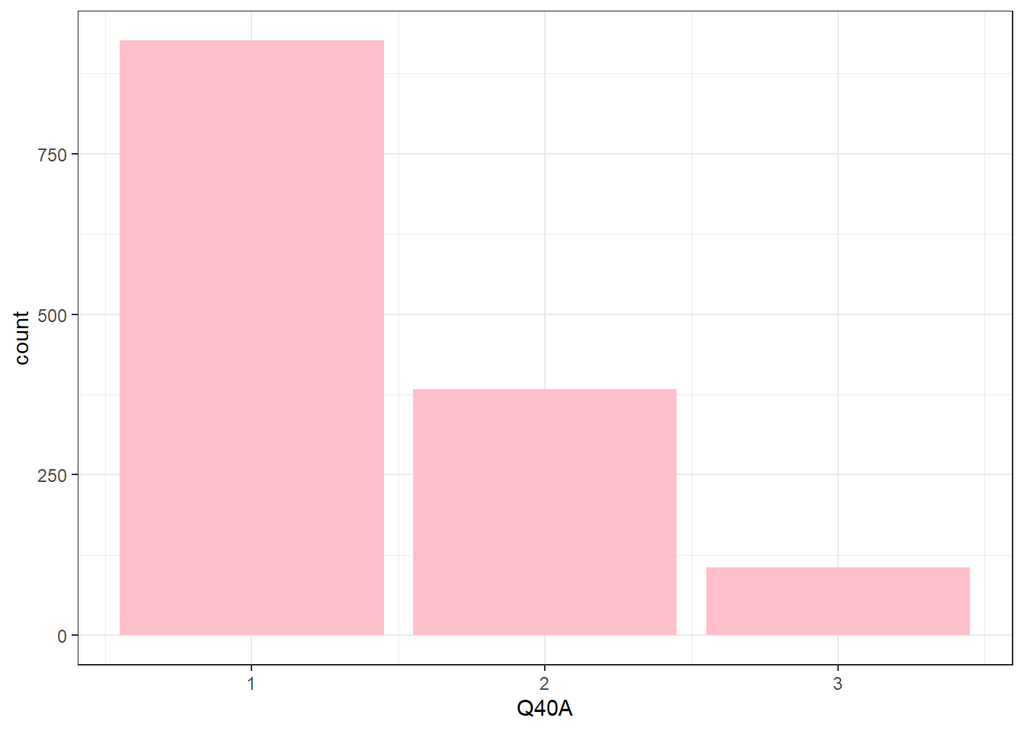

```r
ggplot(data = Base_Trajipaq_Finale_Ok, mapping = aes(x = Q40A)) +
  geom_bar(fill = "pink", na.rm = TRUE) +
  theme_bw()
```

La distribution est asymétrique vers la droite. 65.44% des personnes interrogées disent ne jamais avoir subit de discrimination dans l’emploi au cours des 12 derniers mois précédent la crise du covid 19.

## Q40B. Au cours des 12 mois (avant la crise de la COVID-19), pensez-vous avoir subi des traitements inégalitaires ou des discriminations ? Un traitement inégalitaire ou une discrimination se repère si « vous avez été moins bien traité que les autres, sans raison valable » : dans la recherche de logement ?

```r
Base_Trajipaq_Finale_Ok <-
  Base_Trajipaq_Finale_Ok %>%
  mutate(Q40B = case_when(
    Q40B == 1 ~ 3,
    Q40B == 2 ~ 2,
    Q40B == 3 ~ 1,
    Q40B == 96 ~ NA,
    Q40B == 98 ~ NA,
    Q40B == 99 ~ NA
  ))
```

```r
freq(Base_Trajipaq_Finale_Ok$Q40B)
```

```
## Frequencies
## Base_Trajipaq_Finale_Ok$Q40B
## Type: Numeric
##
##               Freq   % Valid   % Valid Cum.   % Total   % Total Cum.
## ----------- ------ --------- -------------- --------- --------------
##           1   1029     79.64          79.64     65.83          65.83
##           2    195     15.09          94.74     12.48          78.31
##           3     68      5.26         100.00      4.35          82.66
##        <NA>    271                              17.34         100.00
##       Total   1563    100.00         100.00    100.00         100.00
```

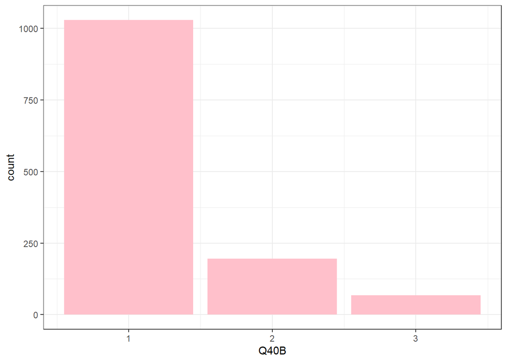

```r
ggplot(data = Base_Trajipaq_Finale_Ok, mapping = aes(x = Q40B)) +
  geom_bar(fill = "pink", na.rm = TRUE) +
  theme_bw()
```

La distribution est asymétrique vers la droite. 79.64% des personnes interrogées disent ne jamais avoir subit de discrimination dans la recherche de logement au cours des 12 derniers mois précédent la crise du covid 19.

## Q40C. Au cours des 12 mois (avant la crise de la COVID-19), pensez-vous avoir subi des traitements inégalitaires ou des discriminations ? Un traitement inégalitaire ou une discrimination se repère si « vous avez été moins bien traité que les autres, sans raison valable » : dans la santé ?

```r
Base_Trajipaq_Finale_Ok <-
  Base_Trajipaq_Finale_Ok %>%
  mutate(Q40C = case_when(
    Q40C == 1 ~ 3,
    Q40C == 2 ~ 2,
    Q40C == 3 ~ 1,
    Q40C == 96 ~ NA,
    Q40C == 98 ~ NA,
    Q40C == 99 ~ NA
  ))
```

```r
freq(Base_Trajipaq_Finale_Ok$Q40C)
```

```
## Frequencies
## Base_Trajipaq_Finale_Ok$Q40C
## Type: Numeric
##
##               Freq   % Valid   % Valid Cum.   % Total   % Total Cum.
## ----------- ------ --------- -------------- --------- --------------
##           1   1155     82.26          82.26     73.90          73.90
##           2    184     13.11          95.37     11.77          85.67
##           3     65      4.63         100.00      4.16          89.83
##        <NA>    159                              10.17         100.00
##       Total   1563    100.00         100.00    100.00         100.00
```

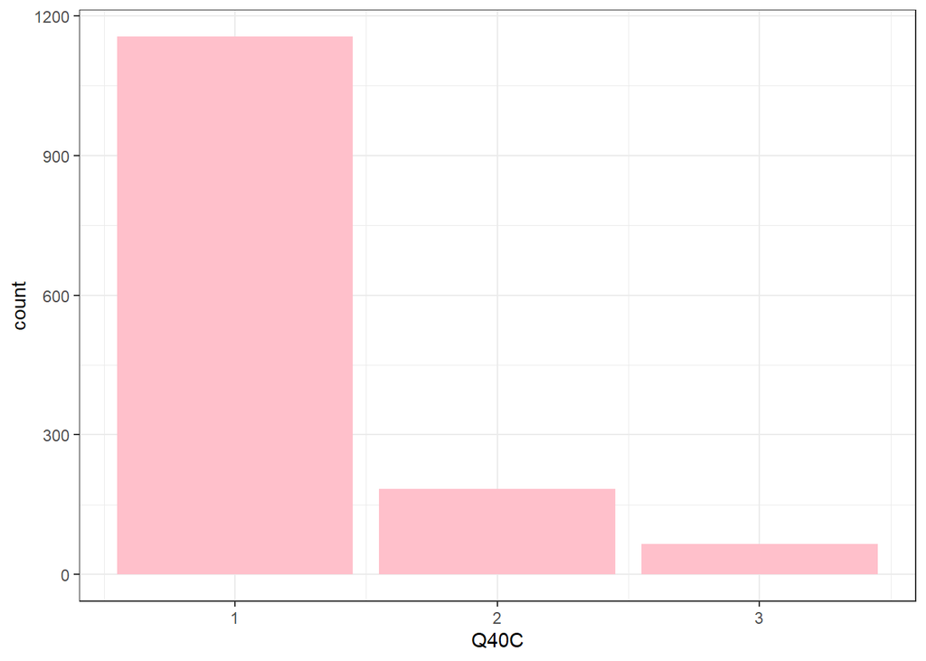

```r
ggplot(data = Base_Trajipaq_Finale_Ok, mapping = aes(x = Q40C)) +
  geom_bar(fill = "pink", na.rm = TRUE) +
  theme_bw()
```

La distribution est asymétrique vers la droite. 82.26% des personnes interrogées disent ne jamais avoir subit de discrimination dans la santé au cours des 12 derniers mois précédent la crise du covid 19.

## Q40D. Au cours des 12 mois (avant la crise de la COVID-19), pensez-vous avoir subi des traitements inégalitaires ou des discriminations ? Un traitement inégalitaire ou une discrimination se repère si « vous avez été moins bien traité que les autres, sans raison valable » : sur le lieu de formation ?

```r
Base_Trajipaq_Finale_Ok <-
  Base_Trajipaq_Finale_Ok %>%
  mutate(Q40D = case_when(
    Q40D == 1 ~ 3,
    Q40D == 2 ~ 2,
    Q40D == 3 ~ 1,
    Q40D == 96 ~ NA,
    Q40D == 98 ~ NA,
    Q40D == 99 ~ NA
  ))
```

```r
freq(Base_Trajipaq_Finale_Ok$Q40D)
```

```
## Frequencies
## Base_Trajipaq_Finale_Ok$Q40D
## Type: Numeric
##
##               Freq   % Valid   % Valid Cum.   % Total   % Total Cum.
## ----------- ------ --------- -------------- --------- --------------
##           1   1072     81.40          81.40     68.59          68.59
##           2    194     14.73          96.13     12.41          81.00
##           3     51      3.87         100.00      3.26          84.26
##        <NA>    246                              15.74         100.00
##       Total   1563    100.00         100.00    100.00         100.00
```

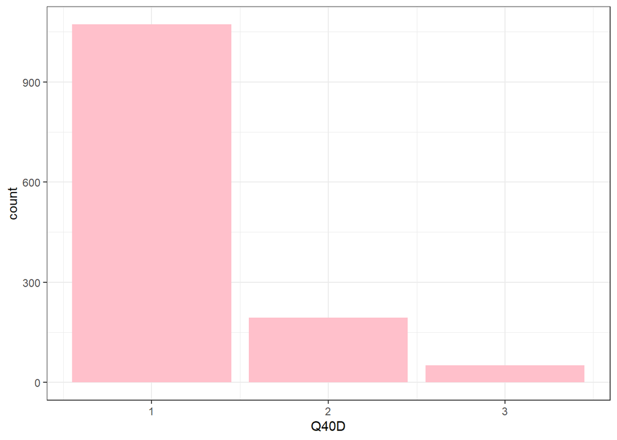

```r
ggplot(data = Base_Trajipaq_Finale_Ok, mapping = aes(x = Q40D)) +
  geom_bar(fill = "pink", na.rm = TRUE) +
  theme_bw()
```

La distribution est asymétrique vers la droite. 81.40% des personnes interrogées disent ne jamais avoir subit de discrimination sur le lieu de formation au cours des 12 derniers mois précédent la crise du covid 19.